# Uso basico del paquete censo2017

Mauricio Vargas S.

2020-10-30

# Introduccion

Este paquete se integra perfectamente con el tidyverse y se dara un ejemplo muy basico para mostrar las principales funciones.

# Aproximacion de la poblacion con el grado de doctor en la Provincia de Santiago

Se procedera a obtener una aproximacion usando dplyr ya que puede haber personas que no son de la comuna y aparecen censadas. Sin embargo no se hara el filtro que corrige esto para mantener el ejemplo lo mas simple posible.

Hay que realizar algunos cruces de tablas de manera de filtrar la region que nos interesa. Comienzo con la tabla zonas, genero la provincia a partir del geocodigo y luego filtro para unir hasta llegar a la tabla personas. Con estos pasos se puede agrupar por zona (o comuna) y obtener la cuenta.

```r
library(censo2017)
library(dplyr)
library(ggplot2)
library(sf)

nivel_educacional <- tbl(censo_bbdd(), "zonas") %>%
    mutate(provincia = substr(as.character(geocodigo), 1, 3)) %>%
    filter(provincia == "131") %>%
    select(geocodigo, zonaloc_ref_id) %>%

    inner_join(select(tbl(censo_bbdd(), "viviendas"), zonaloc_ref_id, vivienda_ref_id), by = "zonaloc_ref_id") %>%
    inner_join(select(tbl(censo_bbdd(), "hogares"), vivienda_ref_id, hogar_ref_id), by = "vivienda_ref_id") %>%
    inner_join(select(tbl(censo_bbdd(), "personas"), hogar_ref_id, nivel_educ = p15), by = "hogar_ref_id") %>%
    collect() %>%

    group_by(geocodigo, nivel_educ) %>%
    summarise(cuenta = n()) %>%
    group_by(geocodigo) %>%
    mutate(proporcion = cuenta / sum(cuenta))

nivel_educacional
```

```
#> # A tibble: 23,330 x 4
#> # Groups:   geocodigo [1,501]
#>    geocodigo   nivel_educ cuenta proporcion
#>    <chr>            <int>  <int>      <dbl>
#>  1 13101011001          1     35   0.0161
#>  2 13101011001          2      7   0.00322
#>  3 13101011001          3     15   0.00690
#>  4 13101011001          4      1   0.000460
#>  5 13101011001          5     94   0.0432
#>  6 13101011001          6     17   0.00782
#>  7 13101011001          7    174   0.0800
#>  8 13101011001          8     99   0.0455
#>  9 13101011001          9     89   0.0409
#> 10 13101011001         10     14   0.00644
#> # … with 23,320 more rows
```

Ahora obtengo el mapa de la provincia y procedo a pegar los datos anteriores a la tabla del mapa. Notese que en esta parte uso `censo_tabla()`, funcion que trae la tabla completa y que me ahorra pasos adicionales con dplyr para transformar la columna `geometry` a un formato adecuado para graficar.

```r
mapa_santiago <- censo_tabla("mapa_zonas") %>%
  filter(provincia == 131) %>%
  left_join(nivel_educacional, by = "geocodigo")
```

Finalmente procedo a generar el mapa.

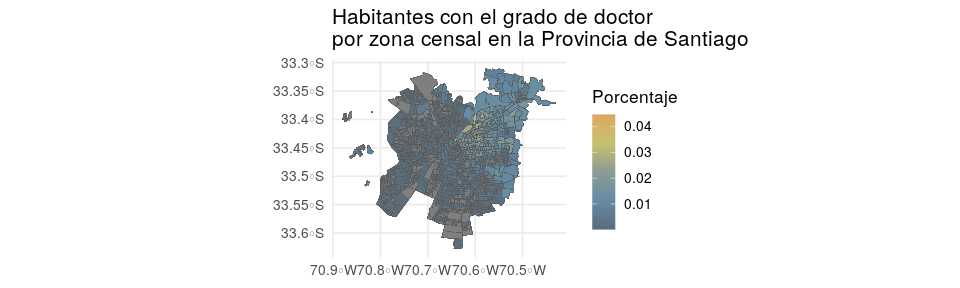

```r
colors <- c("#DCA761","#C6C16D","#8B9C94","#628CA5","#5A6C7A")

g <- ggplot() +
  geom_sf(data = mapa_santiago %>%
            select(geocodigo, geometry) %>%
            left_join(
              mapa_santiago %>%
                st_drop_geometry() %>%
                select(geocodigo, nivel_educ, proporcion) %>%
                filter(nivel_educ == 14),
              by = "geocodigo"
            ),
          aes(fill = proporcion, geometry = geometry),
          size = 0.1) +
  scale_fill_gradientn(colours = rev(colors), name = "Porcentaje") +
  labs(title = "Habitantes con el grado de doctor\npor zona censal en la Provincia de Santiago") +
  theme_minimal(base_size = 13)

g
```

Un ultimo paso, muy importante, es cerrar la conexion a la base de datos.

```r
censo_desconectar_base()
```

Notas:

- El uso de `tbl()` y `collect()` en la primera parte se podra entender mejor leyendo, por ejemplo, [A Crash Course on PostgreSQL for R Users](https://pacha.dev/blog/2020/08/09/a-crash-course-on-postgresql-for-r-users/).
- En la segunda parte se usa `censo_tabla()` ya que SQL almacena la columna `geometry` (de tipo poligono) como cadena de texto mientras que R lee poligonos sin problema.
- En la tercera parte hago un join entre el mapa completo y la tabla con quienes tienen el grado de doctor. Este paso, aunque pueda parecer redundante, es necesario si quiero mostrar las zonas con 0 doctores y si lo omito se borran algunas zonas del mapa.

# Ejercicios para el usuario

1. Realizar un grafico similar al del ejemplo pero a nivel comunal.
2. Explorar la columna `p10` en la tabla `personas` y realizar un grafico que de cuenta de la poblacion efectiva de la comuna (e.g. mejorando el problema de personas que podrian no ser de la comuna en el ejemplo).